# Assignment 2: Snake Game

Introduction to Programming (CSSE7030)  
**Due: 23 October 2026, 15:00 GMT+10**

Published

September 17, 2026

## Introduction

[Snakes and Ladders](https://toytheater.com/snakes-and-ladders/) is a simple board game originating from Ancient India, in which two or more players race to traverse a board. In assignment 2, you will create a simplified version of Snakes and Ladders. This prototype will be a one player game and will be text based. We will also be adding magic potions.

## Getting Started

Download `a2.zip` from Blackboard. This archive contains the necessary files to start your assignment. Once extracted, the `a2.zip` archive will provide the following files:

- `a2.py`: *This is the only file where you write your code* and is the *only* `.py` file you will submit. *Do not* make changes to any other files.
- `support.py`: *Do not modify or submit this file*, it contains pre-defined constants to use in your assignment. In addition to these, you are encouraged to create your own constants in `a2.py` where possible.
- `level1.txt`: An example file for a level. You will need to be able to read and load this level for later tasks. Your finished program will also need to be able to load any text file conforming to this sort of layout. Do not submit this file.
- `gameplay/`: This folder contains a number of example outputs generated by playing the game using a fully-functional completed solution to this assignment. The purpose of the files in this folder is to help you understand how the game works, and how output should be formatted.

If you also wish to download this task sheet you must first click `View Fullscreen` at the top of the page. This will open the task sheet in a new browser tab. On this tab, use `Ctrl-P` to print the page, and select `Save to PDF` as the output location. The print button on Blackboard only captures the first two or so pages of this sheet (a limitation of Blackboard beyond our control).

**Caution**

The task sheet may be modified throughout the course of the assignment as issues are identified. These updates will appear online, but will **not** be reflected in a previously downloaded copy. Please regularly check the changelog **online** to ensure you are working with the most up to date version of the task sheet.

## Gameplay

This section provides a high-level overview of gameplay, and is intended to provide you with an idea of the behaviour of a fully completed assignment. Where interactions are not explicitly mentioned in this section, please see the Implementation section.

**Important**

Do not simply implement the behaviour described here using your own structure; you *must* implement the individual functions, classes, and methods described in the Implementation section. Inputs and outputs must match *exactly* what is expected. Refer to the Implementation section, the given examples, and the provided Gradescope tests for clarification on required prompts and outputs.

In Snake Game, a player starts with a given amount of *health* and a given number of *remaining rolls*. In each turn , the player rolls a dice and moves along a *path*, which is made up of *tiles*. The player moves by the number of steps indicated by the dice roll. Tiles may be a *floor*, or an *exit*. There are also a number of *entities* that exist on the path. The *player* is themselves an entity. Other entities include *snakes*, *ladders* and various types of *potions*.

The objective of the game is for the player to reach the *exit* at the end of the path. The player must land precisely on the exit. For example, if the player is two steps away from the exit and rolls a three, they cannot move and must try again on their next turn. Each dice roll uses one of the player’s remaining rolls.

As the player moves along the path, they may step on snakes, ladders or potions. If the player lands on a snake, they lose one point of health and are sent back to the start of the path. If the player lands on a potion, the potion’s effect is applied to the player and the potion is then removed from the game. If the player lands on a ladder, they are moved forward along the path by the number of steps specified by the ladder’s length.

The path is rectangular in shape and has an alternating pattern. For example, the path below has five rows and three columns:

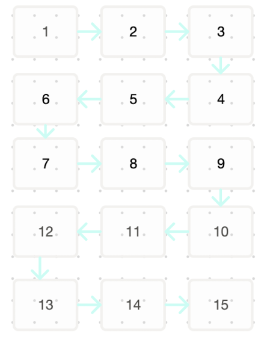

Figure 1: An example of the standard path layout.

Potions are collectable entities which have a number of *effects* that can be applied to increase a player’s health and/or number of remaining rolls, thereby allowing the player to complete games they may otherwise be unable to complete. When the player moves onto a position containing a potion, the potion’s effects are applied to the player and the potion is then removed from the game. Each effect is applied with a value, which determines the strength of the effect. The behavior of each effect is described in Table 1.

Table 1: Potion effects. Effects with names that do not *exactly* match a row on this table do nothing.

| Effect | Behavior |
| --- | --- |
| `health` | The player’s health is increased by the effect value. |
| `rolls` | The player’s remaining rolls is increased by the effect value. |

After starting a Snake Game, a welcome message is displayed, and the following game loop is then repeated:

1. At each turn, the game state is printed to the screen and the player is prompted to press Enter to roll the dice. Once the player presses Enter, the dice is rolled, the result of roll is displayed on the screen, and one of the player’s remaining rolls is consumed.
2. The player is moved along the path by the number of steps indicated by the dice roll. If this move would take the player beyond the exit, a message is displayed indicating the number of steps required to reach the exit. The player is not moved, the turn ends, and the game returns to Step 1.
3. If the player moves and lands on an entity, the corresponding action is performed as described in Table 2. After the action is completed, the turn then ends, and the game returns to Step 1 for the next turn. The game loop continues until one of the following conditions occurs:
- The player *wins* by reaching the exit at the end of the path.
- The player *loses* by running out of remaining rolls before reaching the exit, or by running out of health.

Once the game is over, the final game state is displayed and the player is informed whether they won or lost. The program then terminates gracefully.

Table 2: Actions to take upon landing on various types of entities.

| Entity | Action |
| --- | --- |
| Snake | The player takes 1 point of damage and is sent back to the start of the board. |
| Potion | The potion’s effect is applied to the player. The potion is then removed from the game. |
| Ladder | The player player is sent forward along the path by the given ladder’s length. |

## Implementation

**Important**

You are **not** permitted to add any additional import statements to `a2.py`. Doing so will result in a deduction of up to 100% of your mark. You must not modify or remove the import statements already provided to you in `a2.py`. Removing or modifying these existing import statements may result in your code not functioning, and may result in a deduction of up to 100% of your mark.

### Required Classes and Methods

This section outlines the classes and methods you are **required** to implement in `a2.py`. Your program must operate *exactly* as specified. In particular, your program’s output must match *exactly* with the expected output. Your program will be marked automatically so minor differences in output (such as whitespace or casing) *will* cause tests to fail resulting in *zero marks* for that test.

The class diagram in Figure 2 provides an overview of all of the classes you must implement in your assignment, and the basic relationships between them. The details of these classes and their methods are described in depth later in this section. Within Figure 2:

- Orange classes are those provided to you in the supporting files.
- Green classes are abstract classes (superclasses). However, you are not required to enforce the abstract nature of the green classes in their implementation. The purpose of this distinction is to indicate to you that you should only ever instantiate the blue classes in your program (though you should instantiate the green classes to test them before beginning work on their subclasses).
- Blue classes are concrete classes (subclasses).
- Solid arrows indicate inheritance (i.e. the “is-a” relationship).
- Dotted arrows indicate composition (i.e. the “has-a” relationship). An arrow marked with 1-1 denotes that each instance of the class at the base of the arrow contains exactly one instance of the class at the head of the arrow. An arrow marked with 1-n denotes that each instance of the class at the head of the arrow may contain many instances of the class at the tail of the arrow.

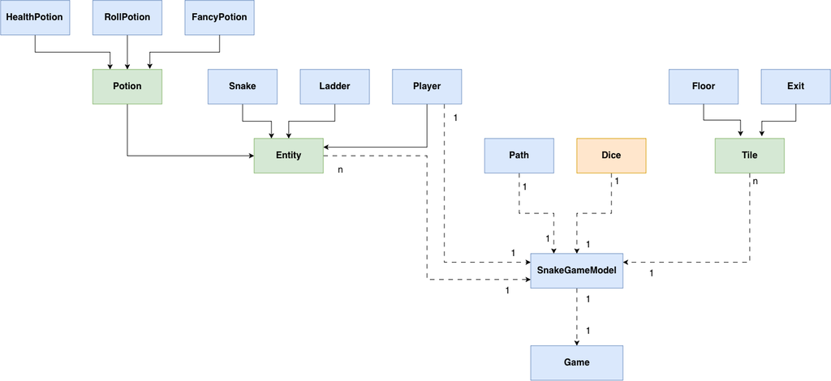

Figure 2: Basic UML diagram for the classes in assignment 2.

**Note**

You are awarded marks for the number of tests passed by your classes when they are tested *independently* of one another. Thus an incomplete assignment with *some* working classes may well be awarded more marks than a complete assignment with faulty classes.

Each class is accompanied with some examples for usage to help you *start* your own testing. You should also test your methods with other values to ensure they operate according to the descriptions.

The rest of this section describes what you must implement in `a2.py` in detail. We recommend that you complete the given tasks in order, ensuring that everything you implement is tested thoroughly, operating correctly, and passes all relevant Gradescope tests.

#### Task 1 `Tile()`

`Tile` is an abstract class from which all instantiated types of tile inherit. This class provides default tile behavior, which can be inherited or overridden by specific types of tile. All tiles are given a single character identifier representing their type.

Abstract tiles have type representation `T`.

`Tile` must implement the following methods:

- `__str__(self) -> str`  
  Returns the single character representing this tile. Unless otherwise specified, this will be the tile’s type representation.
- `__repr__(self) -> str`  
  Returns a string which could be copied and pasted into a REPL to construct a new instance identical to self.
- `get_type(self) -> str` Returns the single character representing the type of this tile.

Example:

```python
>>> tile = Tile()
>>> tile
```

```
Tile()
```

```python
>>> str(tile)
```

```
'T'
```

```python
>>> tile.get_type()
```

```
'T'
```

#### Task 2 `Floor(Tile)`

`Floor` is a tile representing empty space on which entities can freely move. Floor tiles are given a type identifier of a full stop (`.`).

Example:

```python
>>> tile = Floor()
>>> tile
```

```
Floor()
```

```python
>>> str(tile)
```

```
'.'
```

```python
>>> tile.get_type()
```

```
'.'
```

#### Task 3 `Exit(Tile)`

`Exit` is a tile representing the end of the path. Exits are represented by the character `X`.

Example:

```python
>>> tile = Exit()
>>> tile
```

```
Exit()
```

```python
>>> str(tile)
```

```
'X'
```

```python
>>> tile.get_type()
```

```
'X'
```

#### Task 4 `Entity()`

`Entity` is an abstract class from which all instantiated types of entity inherit. This class provides default entity behavior, which can be inherited or overridden by specific types of entity. Each entity occupies a position. Positions are represented as (row, column) integer tuples, where `(0, 0)` denotes the top-left corner of the board. Like tiles, each entity is given a single character identifier representing its type. Base entities have type representation `E`.

`Entity` must implement the following methods:

- `__init__(self, position: tuple[int, int])`  
  Instantiate a new entity at the given position.
- `__repr__(self) -> str`  
  Returns a string which could be copied and pasted into a REPL to construct a new instance identical to self.
- `__str__(self) -> str` Returns the single character representing this entity. Unless otherwise specified, this will be the entity’s type representation.
- `get_type(self) -> str` Returns the single character representing the type of this entity.
- `get_position(self) -> tuple[int, int]`  
  Returns this entity’s position.
- `set_position(self, new_pos: tuple[int, int])`  
  Sets this entity’s position to the specified value.

Example:

```python
>>> entity = Entity((0,1))
>>> entity
```

```
Entity((0, 1))
```

```python
>>> str(entity)
```

```
'E'
```

```python
>>> entity.get_type()
```

```
'E'
```

```python
>>> entity.get_position()
```

```
(0, 1)
```

```python
>>> entity.set_position((6,7))
>>> entity
```

```
Entity((6, 7))
```

```python
>>> entity.get_position()
```

```
(6, 7)
```

#### Task 5 `Potion(Entity)`

A `Potion` is an abstract class which provides a simple interface which all instances of potions must implement.

Abstract potions have type representation `O` and no effects.

In addition to the `Entity` methods that must be supported, `Potion` must implement the following methods:

- `get_effect(self) -> dict[str, int]`  
  Returns this potion’s effect.

Example:

```python
>>> potion = Potion((0,1))
>>> potion
```

```
Potion((0, 1))
```

```python
>>> str(potion)
```

```
'O'
```

```python
>>> potion.get_type()
```

```
'O'
```

```python
>>> potion.get_position()
```

```
(0, 1)
```

```python
>>> potion.get_effect()
```

```
{}
```

#### Task 6 `HealthPotion(Potion)`

A `HealthPotion` is a sour tasting potion that increases the player’s `health` by 1. Health potions have the type representation `H`.

Example:

```python
>>> potion = HealthPotion((0,1))
>>> potion
```

```
HealthPotion((0, 1))
```

```python
>>> str(potion)
```

```
'H'
```

```python
>>> potion.get_type()
```

```
'H'
```

```python
>>> potion.get_position()
```

```
(0, 1)
```

```python
>>> potion.get_effect()
```

```
{'health': 1}
```

#### Task 7 `RollPotion(Potion)`

A `RollPotion` is a fruity tasting potion that provides the player with 3 additional `rolls`. Roll potions have the type representation `R`.

Example:

```python
>>> potion = RollPotion((0,1))
>>> potion
```

```
RollPotion((0, 1))
```

```python
>>> str(potion)
```

```
'R'
```

```python
>>> potion.get_type()
```

```
'R'
```

```python
>>> potion.get_position()
```

```
(0, 1)
```

```python
>>> potion.get_effect()
```

```
{'rolls': 3}
```

#### Task 8 `FancyPotion(Potion)`

A `FancyPotion` increases the player’s `health` by 2 and their remaining `rolls` by 2 (Very Fancy). Fancy Potions have the type representation `F`.

**Note**

It’s unclear what Fancy Potions taste like. Many people claim they taste like White Monster, however there’s an opposing camp who argue the taste is closer to La Croix.

Example:

```python
>>> potion = FancyPotion((0,1))
>>> potion
```

```
FancyPotion((0, 1))
```

```python
>>> str(potion)
```

```
'F'
```

```python
>>> potion.get_type()
```

```
'F'
```

```python
>>> potion.get_position()
```

```
(0, 1)
```

```python
>>> potion.get_effect()
```

```
{'health': 2, 'rolls': 2}
```

#### Task 9 `Snake(Entity)`

A `Snake` is an entity that sits on the board and is represented by `S`.

**Note**

The Snake class should not handle the damage caused to a player who lands on a snake. Instead, this interaction should be handled by the SnakeGameModel class, which is responsible for managing interactions between entities.

Example:

```python
>>> snake = Snake((0,1))
>>> snake
```

```
Snake((0, 1))
```

```python
>>> str(snake)
```

```
'S'
```

```python
>>> snake.get_type()
```

```
'S'
```

```python
>>> snake.get_position()
```

```
(0, 1)
```

#### Task 10 `Ladder(Entity)`

A `Ladder` is an entity that sits on the board and is represented by `L`. Players who step on Ladders will be moved forwards a given number of places.

To support this extended functionality, the `__init__` method of `Ladder` takes in an additional argument. In addition to the `Entity` methods that must be supported, `Ladder` must implement the following methods:

- `__init__(self, position: tuple[int, int], length: int)`  
  Instantiate a new ladder of specified length at the given position.
- `__str__(self) -> str`  
  Returns a string containing this ladder’s length.
- `get_length(self) -> int`  
  Returns this ladder’s length.

Example:

```python
>>> ladder = Ladder((0,1), 6)
>>> ladder
```

```
Ladder((0, 1), 6)
```

```python
>>> str(ladder)
```

```
'6'
```

```python
>>> ladder.get_type()
```

```
'L'
```

```python
>>> ladder.get_position()
```

```
(0, 1)
```

```python
>>> ladder.get_length()
```

```
6
```

#### Task 11 `Player(Entity)`

`Player` denotes the entity directly controlled by the player. Player entities possess both a `health` value and a number of remaining `rolls`. These values may change throughout gameplay. Player instances have the type identifier `P`.

To support this extended functionality, The `__init__` method of `Player` takes in two additional arguments. In addition to the `Entity` methods that must be supported, `Player` must implement the following methods:

- `__init__(self, position: tuple[int, int], health: int, remaining_rolls: int)` Instantiate a new player at the given position, with the specified health and remaining rolls.
- `get_health(self) -> int`  
  Return this player’s current health.
- `add_health(self, amount: int)`  
  Add the given amount to this player’s health.
- `get_remaining_rolls(self) -> int`  
  Return the number of remaining rolls this player has.
- `add_remaining_rolls(self, rolls: int)`  
  Add the given number of rolls to the remaining rolls of this player instance.
- `apply_effect(self, effect: dict[str, int])`  
  Apply the given potion’s effects to this player.
- `has_finished(self) -> bool` Indicates whether this player has finished traversing the board.
- `finish(self)` Signal to this instance that it has finished traversing the board.
- `is_alive(self) -> bool` Indicates whether this instance of the player is alive.
- `has_remaining_rolls(self) -> bool` Indicates whether this player has any remaining rolls.

Example:

```python
>>> player = Player((0,1), 4, 2)
>>> player
```

```
Player((0, 1), 4, 2)
```

```python
>>> str(player)
```

```
'P'
```

```python
>>> player.get_type()
```

```
'P'
```

```python
>>> player.get_position()
```

```
(0, 1)
```

```python
>>> player.get_health()
```

```
4
```

```python
>>> player.add_health(1)
>>> player
```

```
Player((0, 1), 5, 2)
```

```python
>>> player.get_health()
```

```
5
```

```python
>>> player.is_alive()
```

```
True
```

```python
>>> player.add_health(-10)
>>> player.is_alive()
```

```
False
```

```python
>>> player.get_remaining_rolls()
```

```
2
```

```python
>>> player.add_remaining_rolls(2)
>>> player
```

```
Player((0, 1), -5, 4)
```

```python
>>> player.get_remaining_rolls()
```

```
4
```

```python
>>> player.has_remaining_rolls()
```

```
True
```

```python
>>> player.add_remaining_rolls(-4)
>>> player.has_remaining_rolls()
```

```
False
```

```python
>>> player.has_finished()
```

```
False
```

```python
>>> player.finish()
>>> player.has_finished()
```

```
True
```

```python
>>> player.apply_effect({})
>>> player
```

```
Player((0, 1), -5, 0)
```

```python
>>> player.get_health()
```

```
-5
```

```python
>>> player.get_remaining_rolls()
```

```
0
```

```python
>>> player.apply_effect({
    'health': 6,
    'rolls': 2
})
>>> player
```

```
Player((0, 1), 1, 2)
```

```python
>>> player.get_health()
```

```
1
```

```python
>>> player.get_remaining_rolls()
```

```
2
```

#### Task 12 `read_file(board_file: str) -> tuple[list[Tile], list[Entity], Player]`

`read_file` is a helpful *function* that loads the tiles, entities, and player comprising a Snake Game from a text file.

You may assume that the file specified by `board_file` contains *exactly* the following:

- A single line containing exactly two integers, corresponding to the player’s health and remaining moves in that order. This is followed immediately by:
- A rectangular grid of single characters, denoting the board and the entities contained within it.

Within the rectangular grid, the character at each position is the string representation of the tile at that position on the board. If there is an entity at a given position on the board, the character at that position in the grid is instead the string representation of that entity. You may (and indeed must) assume that all entities present on the board are located on `Floor` tiles.

The list of entities that you return should not include the player entity, and should be ordered by entity position: from top to bottom with ties being broken from left to right.

**Tip**

`level1.txt` is an example of files that this function is expected to parse

Example:

```python
>>> tiles, entities, player = read_file('levels/level1.txt')
>>> tiles
```

```
[[Floor(), Floor(), Floor(), Floor(), Floor()],
 [Floor(), Floor(), Floor(), Floor(), Floor()],
 [Floor(), Floor(), Floor(), Floor(), Floor()],
 [Floor(), Floor(), Floor(), Floor(), Floor()],
 [Floor(), Floor(), Floor(), Floor(), Exit()]]
```

```python
>>> entities
```

```
[HealthPotion((0, 3)),
 Snake((1, 1)),
 Ladder((1, 3), 3),
 RollPotion((2, 2)),
 Snake((2, 4)),
 Ladder((3, 0), 4),
 FancyPotion((3, 1))]
```

```python
>>> player
```

```
Player((0, 0), 3, 15)
```

#### Task 13 `Path()`

A Path abstracts the route that the player must follow through the board. Its responsibility is to handle the translation between one-dimensional path positions and two-dimensional board positions (see the figure provided in the Gameplay Section).

This assignment is not prescriptive about internal representation of `path` (within reason, of course), however a `Path` must support the following interface:

- `__init__(self, row_count: int, column_count: int)` Instantiate a new path for a board with the given number of rows and columns.
- `get_position(self, index: int) -> tuple[int, int] | None`  
  Get the two dimensional board position corresponding to the given one dimensional path position. If the index does not correspond to a position on the board, return `None`.
- `get_index(self, position: tuple[int,int]) -> int | None`  
  Get the one dimensional path position corresponding to the given two dimensional board position. If the position does not occur on the board, return `None`.
- `get_length(self) -> int` Get the length of this path.

Example:

```python
>>> path = Path(5, 3)
>>> path.get_length()
```

```
15
```

```python
>>> path.get_position(5)
```

```
(1, 0)
```

```python
>>> path.get_index((1, 2))
```

```
3
```

```python
>>> position = path.get_position(16)
>>> print(position, type(position))
```

```
None <class 'NoneType'>
```

```python
>>> index = path.get_index((6, 2))
>>> print(index, type(index))
```

```
None <class 'NoneType'>
```

#### Task 14 `SnakeGameModel()`

The `SnakeGameModel` class is responsible for maintaining the game state, and applying game logic.

`SnakeGameModel` must implement the following methods:

- `__init__(self, tiles: list[Tile], entities: list[Entity], player: Player)`  
  Instantiates a new `SnakeGameModel` using the given tiles, entities, and player.
- `get_tiles(self) -> list[Tile]`  
  Return this model’s tiles.
- `get_tile(self, position: tuple[int, int]) -> Tile` Return the Tile at the given position. You may assume the position is valid.
- `get_player(self) -> Player` Return this model’s player instance.
- `entity_positions(self) -> dict[tuple[int, int], Entity]`  
  Returns a dictionary mapping the position of each non-player entity to the corresponding entity instance.
- `get_entity(self, position: tuple[int, int]) -> Entity | None` Return the entity on the board at the given position, if no entity exists at that position, or if the position isn’t on the board, this method should return None.
- `remove_entity(self, entity: Entity) -> None` Remove the given entity from the board. If the entity does not exist anywhere on the position, then nothing should happen.
- `has_lost(self) -> bool`  
  Return `True` if the player has lost the game per the Gameplay section, and `False` otherwise.
- `has_won(self) -> bool`  
  Return `True` if the player has won the game per the Gameplay section, and `False` otherwise.
- `move_player(self, steps: int) -> None`  
  Attempts to move the player forward by the given number of steps as per the rules given in the Gameplay section. After calling this method, effects related to stepping on entities or tiles should have been applied (that is to say, interaction logic should either be handled in this method, or any helper methods it calls).
- `take_turn(self) -> None` Take one turn of the game. In each turn, dice is rolled, the number rolled is displayed, and then the player is moved forward by the number rolled. The player’s movement, including the effects of any snake or ladder encountered, is handled by `move_player`.

**Caution**

Some of these methods will become *very long*. You will likely benefit from adding extra helper methods to this class to help break up some of these long methods (adding helper methods also won’t hurt your style marks).

Example:

```python
>>> tiles, entities, player = read_file('levels/level1.txt')
>>> model = SnakeGameModel(tiles, entities, player)
>>> model.get_tiles()
```

```
[[Floor(), Floor(), Floor(), Floor(), Floor()],
 [Floor(), Floor(), Floor(), Floor(), Floor()],
 [Floor(), Floor(), Floor(), Floor(), Floor()],
 [Floor(), Floor(), Floor(), Floor(), Floor()],
 [Floor(), Floor(), Floor(), Floor(), Exit()]]
```

```python
>>> model.get_player()
```

```
Player((0, 0), 3, 15)
```

```python
>>> model.entity_positions()
```

```
{(0, 3): HealthPotion((0, 3)),
 (1, 1): Snake((1, 1)),
 (1, 3): Ladder((1, 3), 3),
 (2, 2): RollPotion((2, 2)),
 (2, 4): Snake((2, 4)),
 (3, 0): Ladder((3, 0), 4),
 (3, 1): FancyPotion((3, 1))}
```

```python
>>> model.has_won()
```

```
False
```

```python
>>> model.has_lost()
```

```
False
```

```python
>>> model.get_player().add_remaining_rolls(-20)
>>> model.get_player().get_remaining_rolls() <= 0
```

```
True
```

```python
>>> model.has_won()
```

```
False
```

```python
>>> model.has_lost()
```

```
True
```

```python
>>> player = model.get_player()
>>> player.finish()
>>> model.has_won()
```

```
True
```

```python
>>> model.has_lost()
```

```
True
```

```python
>>> model.get_player()
```

```
Player((0, 0), 3, -5)
```

```python
>>> model.get_tiles()
```

```
[[Floor(), Floor(), Floor(), Floor(), Floor()],
 [Floor(), Floor(), Floor(), Floor(), Floor()],
 [Floor(), Floor(), Floor(), Floor(), Floor()],
 [Floor(), Floor(), Floor(), Floor(), Floor()],
 [Floor(), Floor(), Floor(), Floor(), Exit()]]
```

```python
>>> model.get_tile((0,1))
```

```
Floor()
```

```python
>>> model.entity_positions()
```

```
{(0, 3): HealthPotion((0, 3)),
 (1, 1): Snake((1, 1)),
 (1, 3): Ladder((1, 3), 3),
 (2, 2): RollPotion((2, 2)),
 (2, 4): Snake((2, 4)),
 (3, 0): Ladder((3, 0), 4),
 (3, 1): FancyPotion((3, 1))}
```

```python
>>> ladder = model.get_entity((3,0))
>>> model.remove_entity(ladder)
```

```python
>>> model.entity_positions()
```

```
{(0, 3): HealthPotion((0, 3)),
 (1, 1): Snake((1, 1)),
 (1, 3): Ladder((1, 3), 3),
 (2, 2): RollPotion((2, 2)),
 (2, 4): Snake((2, 4)),
 (3, 1): FancyPotion((3, 1))}
```

```python
>>> model.move_player(3)
```

```python
>>> model.entity_positions()
```

```
{(1, 1): Snake((1, 1)),
 (1, 3): Ladder((1, 3), 3),
 (2, 2): RollPotion((2, 2)),
 (2, 4): Snake((2, 4)),
 (3, 1): FancyPotion((3, 1))}
```

```python
>>> model.get_player()
```

```
Player((0, 3), 4, -6)
```

```python
>>> model.move_player(5)
>>> model.get_player()
```

```
Player((0, 0), 3, -7)
```

```python
>>> model.take_turn()
```

```
You rolled 2.
```

```python
>>> model.get_player()
```

```
Player((0, 2), 3, -8)
```

#### Task 15 `Game()`

`Game` represents a complete Snake Game. This class is responsible for handling input and output in order to play a game from start to end.

**Note**

One of the most important skills in programming is the ability to understand and use someone else’s code. You will be expected to be familiar with, and use, the functions and constants provided in `support.py`.

`Game()` should implement the following methods:

- `__init__(self, board_file: str)`  
  Constructs a new `Game` instance, including loading the game state from the specified file and constructing a corresponding `SnakeGameModel`.
- `display(self)`  
  Prints the current game state to the screen in a visually appealing format. The display should contain a rectangular grid of characters representing the board, as would be seen in a level file, followed by the player’s health and remaining rolls. The exact format expected by gradescope is given in the examples present in the `gameplay/` folder.
- `play(self)`  
  Conducts a *Snake Game* from start to finish, following the Gameplay section. See the `gameplay/` folder for example output from this method.

#### Task 16 `main()`

The purpose of the main function is to allow you to test your own code. The main function should be short and do exactly two things: make a new game and play it.

## Assessment and Marking Criteria

This assignment assesses following course learning objectives:

1. Apply program constructs such as variables, selection, iteration and sub-routines,
2. Apply basic object-oriented concepts such as classes, instances and methods,
3. Read and analyse code written by others,
4. Analyse a problem and design an algorithmic solution to the problem,
5. Read and analyse a design and be able to translate the design into a working program, and
6. Apply techniques for testing and debugging.

There are a total of 100 marks for this assessment item.

### Functionality

Your program’s functionality will be marked out of a total of 55 marks.

Your assignment will be put through a series of tests and your functionality mark will be proportional to the number of tests you pass. You will be given a *subset* of the functionality tests before the due date for the assignment.

You may receive partial marks within each section for partially working functions, or for implementing only a few functions.

**Warning**

You need to perform your *own* testing of your program to make sure that it meets **all** specifications given in the assignment. Only relying on the provided tests is likely to result in your program failing in some cases and you losing some functionality marks.

**Note**

Functionality tests are automated, so string outputs need to match *exactly* what is expected.

Your program must run in Gradescope, which uses Python 3.12. Partial solutions will be marked but if there are errors in your code that cause the interpreter to fail to execute your program, you will get zero for functionality marks. If there is a part of your code that causes the interpreter to fail, comment out the code so that the remainder can run. Your program must run using the Python 3.12 interpreter. If it runs in another environment (e.g. Python 3.8 or PyCharm) but not in the Python 3.12 interpreter, you will get zero for the functionality mark. Python versions newer than 3.12 will function correctly provided you do not use language features that are not introduced in the course.

### Code Style

The style of your assignment will be assessed by a tutor. Style will be marked according to the style rubric provided with the assignment. The style mark will be out of 45.

**Note**

Style accounts for 45% of the marks available on this assignment

You are expected to follow the [PEP-8 based style guidelines](https://edstem.org/au/courses/37122/lessons/111845/slides/771271) discussed in lectures. The key consideration in marking your code style is whether the code is easy to understand. There are several aspects of code style that contribute to how easy it is to understand code. In this assignment, your code style will be assessed against the following criteria:

- Readability
  - Program Structure: Layout of code makes it easy to read and follow its logic. This includes using whitespace to highlight blocks of logic, and ensuring all lines are below 80 characters.
  - Descriptive Identifier Names: Variable, constant, and function names clearly describe what they represent in the program’s logic. Do not use Hungarian Notation for identifiers. In short, this means do not include the identifier’s type in its name, rather make the name meaningful (e.g. employee identifier).
  - Named Constants: Any non-trivial fixed value (literal constant) in the code is represented by a descriptive named constant (identifier).
- Algorithmic Logic
  - Single Instance of Logic: Blocks of code should not be duplicated in your program. Any code that needs to be used multiple times should be implemented as a function.
  - Variable Scope: Variables should be declared locally in the function in which they are needed. Global variables should not be used.
  - Control Structures: Logic is structured simply and clearly through good use of control structures (e.g. loops and conditional statements).
- Object-Oriented Program Structure
  - Classes & Instances: Objects are used as entities to which messages are sent, demonstrating understanding of the differences between classes and instances.
  - Encapsulation: Classes are designed as independent modules with state and behaviour. Methods only directly access the state of the object on which they were invoked. Methods never update the state of another object.
  - Abstraction: Public interfaces of classes are simple and reusable. Enabling modular and reusable components which abstract details.
  - Inheritance & Polymorphism: Subclasses are designed as specialised versions of their superclasses. Subclasses extend the behaviour of their superclass without re-implementing behaviour, or breaking the superclass behaviour or design. Subclasses redefine behaviour of appropriate methods to extend the superclasses’ type. Subclasses do not break their superclass’ interface.
- Documentation:
  - Comment Clarity: Comments provide meaningful descriptions of the code. They should not repeat what is already obvious by reading the code (e.g. `# Setting variable to 0`). Comments should not be verbose or excessive, as this can make it difficult to follow the code. Comments must be written in English.
  - Informative Docstrings: Every function should have a docstring that summarises its purpose. This includes describing parameters and return values (including type information) so that others can understand how to use the function correctly.
  - Description of Logic: All significant blocks of code should have a comment (in English) to explain how the logic works. For a small function, this would usually be the docstring. For long or complex functions, there may be different blocks of code in the function. Each of these should have an in-line comment describing the logic.

### Assignment Submission

You must submit your assignment electronically via [Gradescope](https://gradescope.com/). You **must** use your UQ email address which is based on your student number (e.g. `s4123456@student.uq.edu.au`) as your Gradescope submission account.

When you login to Gradescope you may be presented with a list of courses. Select `CSSE7030`. You will see a list of assignments. Choose `Assignment 2`. You will be prompted to choose a file to upload. Do *not* select the option to submit using a git repository if it is presented to you. The prompt may say that you can upload any files, including zip files. You **must** submit your assignment as a single Python file called `a2.py` (use this name – all lower case), and *nothing* else. Your submission will be automatically run to determine the functionality mark. If you submit a file with a different name, the tests will **fail** and you will get **zero** for functionality. Do **not** submit *any* sort of archive file (e.g. zip, rar, 7z, etc.).

Upload an initial version of your assignment *at least* one week before the due date. Do this even if it is just the initial code provided with the assignment. If you are unable access Gradescope, make a post on [Edstem](https://edstem.org/au/courses/37122/discussion) *immediately*. Excuses, such as you were not able to login or were unable to upload a file will not be accepted as reasons for granting an extension.

When you upload your assignment it will run a set of the functionality autograder tests on your submission. It will show you the results of these tests. It is your responsibility to ensure that your uploaded assignment file runs and that it passes the tests you expect it to pass.

### Plagiarism and Reference of AI Use

To pass this assessment, students will be required to demonstrate detailed comprehension of their written submission independent of AI and MT tools. Plesae note that AI or MT tools are not required to be used and not recommended to be used as they may inhibit learning and introduce bugs into your code. You must always follow the referencing requirements. Please refer to the course [AI Guideline](https://learn.uq.edu.au/ultra/courses/_206568_1/document/_13647138_1?view=content&state=view). Failure to appropriately reference the resources (tools and information sources) used in your work may result in misconduct allegations against you. You must clearly reference any use of AI in each instance. You are encouraged to discuss the concepts behind the assignments but under no circumstances should you show your code to, or allow your code to be seen by, another student. You should not look at the code of any other student. You must sufficiently protect all electronic and paper copies of your code. All submitted code will be subject to electronic plagiarism and collusion detection. **Assignments with no academic merit will be awarded a mark of zero.**

**Important**

You **must** understand all code submitted and submit a **PDF or WORD file in English** alongside with your code submission. This file must provide detailed information about how the AI tools were used. Please refer to the [AI Guideline](https://learn.uq.edu.au/ultra/courses/_206568_1/document/_13647138_1?view=content&state=view) for guidance on properly documenting interactions with AI.

You are encouraged to complete *both* parts A and B of the [academic integrity modules](https://web.library.uq.edu.au/library-services/it/learnuq-blackboard-help/academic-integrity-modules) *before* starting this assignment. Submitted assignments will be electronically checked for potential cases of plagiarism.

### Assessment Interviews

Students must be able to demonstrate detailed comprehension of their submitted code independent of AI and machine-translation (MT) tools. The Course Coordinator reserves the right to require any student to participate in an oral examination regarding any assessment submission. During such an examination, students may be required to explain and/or modify their submitted code to demonstrate understanding. Assessment marks are provisional and subject to confirmation following any such examination. A student’s assessment mark may be adjusted, including reduced to zero, based on the level of understanding demonstrated during this examination.

During the examination, students may not use notes or modified code and must work exclusively from the code exactly as submitted. Failure to attend a scheduled examination without an approved reason, or failure to meaningfully participate, will be treated as unsatisfactory performance and may result in the relevant assessment mark being reduced, including to zero. Oral examinations will be scheduled on a case-by-case basis.